# final_project

Yu He

2023-03-13

## Overview of dataset: The Youth Risk Behavior Surveillance System (YRBSS) 2019 high school data for all states

The Youth Risk Behavior Surveillance System (YRBSS) monitors six categories of health-related behaviors that contribute to the leading causes of death and disability among youth and adults, including—

- Behaviors that contribute to unintentional injuries and violence
- Sexual behaviors related to unintended pregnancy and sexually transmitted diseases, including HIV infection
- Alcohol and other drug use
- Tobacco use
- Unhealthy dietary behaviors
- Inadequate physical activity

Database website: https://www.cdc.gov/healthyyouth/data/yrbs/index.htm

Codebook for variable included in the dataset -

- sitename - Name of location covered by a survey
- year - 4-digit year of survey – 1991, 1993, etc
- weight - Analytical weight – used in statistical analyses
- age - Data from: How old are you? A. 12 years old or younger B. 13 years old C. 14 years old D. 15 years old E. 16 years old F. 17 years old G. 18 years old or older
- sex - Data from: What is your sex? A. Female B. Male
- grade - Data from: In what grade are you? A. 9th grade B. 10th grade C. 11th grade D. 12th grade E. Ungraded or other grade
- race4 - 4-level variable from race and ethnicity questions: 1 = “White” 2 = “Black or African American” 3 = “Hispanic/Latino” 4 = “All Other Races”
- race7 - 7-level variable from race and ethnicity questions: 1 = “American Indian/Alaska Native” 2 = “Asian” 3 = “Black or African American” 4 = “Hispanic/Latino” 5 = “Native Hawaiian/Other Pacific Islander” 6 = “White” 7 = “Multiple Races (Non-Hispanic)”
- stheight - Data from: How tall are you without your shoes on?
- bmi - Body mass index (BMI)
- bmipct - Student’s BMI percentile
- qnobese - 1 = obese (when BMI percentile is at or above the 95th percentile for BMI by age and sex) 2 = No
- sexid - Sexual identity: 1 = “Heterosexual” 2 = “Gay or Lesbian” 3 = “Bisexual” 4 = “Not Sure”
- qnfrcig - Currently smoked cigarettes frequently 1 = Yes 2 = No
- qnothhpl - Used birth control pills; an IUD (such as Mirena or ParaGard) or implant (such as Implanon or Nexplanon); or a shot (such as Depo-Provera), patch (such as OrthoEvra), or birth control ring (such as NuvaRing) before last sexual intercourse 1 = Yes 2 = No
- qfoodallergy - Food allergies 1 = Yes 2 = No 3 = Not sure
- qncurrentasthma - Current asthma 1 = Yes 2 = No 3 = Not sure
- qncurrentopioid - Currently took prescription pain medicine without a doctor’s prescription or differently than how a doctor told them to use it

## load libraries

```r
library(tidyverse)
library(haven)
library(caret)
```

```r
library(rpart)
library(rpart.plot)
library(pROC)
library(e1071)
```

## Step 1, data import and process, save the processed sas7dbat data into csv file to improve R runnig time. Only run one time.

```r
# set path
setwd("~/Desktop/CU Spring 2023/P8451 intro to machine learning for EPI/p8451_final_project")

# load state data a_m
#df_a_m = read_sas("sadc_2019_state_a_m.sas7bdat") %>%
#  janitor::clean_names() %>%
#  select(sitename, year, weight, age, sex, grade, race4, race7, stheight, bmi, bmipct, qnobese, sexid, qnfrcig,
#         qnothhpl, qfoodallergy, qncurrentasthma, qncurrentopioid)

# save the data as a CSV file
# write.csv(df_a_m, "df_a_m.csv", row.names = FALSE)

# load state data n_z
#df_n_z = read_sas("sadc_2019_state_n_z.sas7bdat") %>%
#  janitor::clean_names() %>%
#    select(sitename, year, weight, age, sex, grade, race4, race7, stheight, bmi, bmipct, qnobese, sexid, qnfrcig,
#         qnothhpl, qfoodallergy, qncurrentasthma, qncurrentopioid)

# save the data as a CSV file
#write.csv(df_n_z, "df_n_z.csv", row.names = FALSE)
```

## assess the pattern of missing variables

```r
# load the processed data
df_part1 = read_csv("df_a_m.csv")
df_part2 = read_csv("df_n_z.csv")
# merge two dataset
df_f_project = bind_rows(df_part1, df_part2)
```

```r
# find the number of missing observation in each variables in df_f_project
colSums(is.na(df_f_project))
```

```
##        sitename            year          weight             age             sex
##               0               0               0           11931           10638
##           grade           race4           race7        stheight             bmi
##           20174           53974           58783          304533          289901
##          bmipct         qnobese           sexid         qnfrcig        qnothhpl
##          299142          299142          858776           70839         1379057
##    qfoodallergy qncurrentasthma qncurrentopioid
##         1516506         1173351         1485815
```

```r
# find the proportion of missing observation in each variables in df_f_project
colMeans(is.na(df_f_project))
```

```
##        sitename            year          weight             age             sex
##     0.000000000     0.000000000     0.000000000     0.007796052     0.006951169
##           grade           race4           race7        stheight             bmi
##     0.013182261     0.035268134     0.038410471     0.198990453     0.189429492
##          bmipct         qnobese           sexid         qnfrcig        qnothhpl
##     0.195467822     0.195467822     0.561148465     0.046288201     0.901114749
##    qfoodallergy qncurrentasthma qncurrentopioid
##     0.990927803     0.766700645     0.970873437
```

```r
summary(df_f_project)
```

```
##    sitename              year          weight              age
##  Length:1530390     Min.   :1991   Min.   :   0.343   Min.   :1.000
##  Class :character   1st Qu.:2005   1st Qu.:   5.894   1st Qu.:4.000
##  Mode  :character   Median :2011   Median :  23.050   Median :5.000
##                     Mean   :2010   Mean   :  66.613   Mean   :4.891
##                     3rd Qu.:2015   3rd Qu.:  86.501   3rd Qu.:6.000
##                     Max.   :2019   Max.   :4035.663   Max.   :7.000
##                                                       NA's   :11931
##       sex            grade           race4           race7
##  Min.   :1.000   Min.   :1.000   Min.   :1.00    Min.   :1.00
##  1st Qu.:1.000   1st Qu.:1.000   1st Qu.:1.00    1st Qu.:4.00
##  Median :1.000   Median :2.000   Median :1.00    Median :6.00
##  Mean   :1.492   Mean   :2.358   Mean   :1.81    Mean   :5.02
##  3rd Qu.:2.000   3rd Qu.:3.000   3rd Qu.:3.00    3rd Qu.:6.00
##  Max.   :2.000   Max.   :4.000   Max.   :4.00    Max.   :7.00
##  NA's   :10638   NA's   :20174   NA's   :53974   NA's   :58783
##     stheight           bmi             bmipct          qnobese
##  Min.   :1.02     Min.   :  0.00   Min.   : 0.00    Min.   :1.00
##  1st Qu.:1.63     1st Qu.: 19.97   1st Qu.:39.91    1st Qu.:2.00
##  Median :1.70     Median : 22.04   Median :66.46    Median :2.00
##  Mean   :1.69     Mean   : 23.18   Mean   :61.56    Mean   :1.87
##  3rd Qu.:1.78     3rd Qu.: 25.11   3rd Qu.:87.13    3rd Qu.:2.00
##  Max.   :2.41     Max.   :218.56   Max.   :99.97    Max.   :2.00
##  NA's   :304533   NA's   :289901   NA's   :299142   NA's   :299142
##      sexid           qnfrcig         qnothhpl        qfoodallergy
##  Min.   :1.0      Min.   :1.00    Min.   :1.0       Min.   :1
##  1st Qu.:1.0      1st Qu.:2.00    1st Qu.:1.0       1st Qu.:2
##  Median :1.0      Median :2.00    Median :2.0       Median :2
##  Mean   :1.3      Mean   :1.93    Mean   :1.7       Mean   :2
##  3rd Qu.:1.0      3rd Qu.:2.00    3rd Qu.:2.0       3rd Qu.:2
##  Max.   :4.0      Max.   :2.00    Max.   :2.0       Max.   :3
##  NA's   :858776   NA's   :70839   NA's   :1379057   NA's   :1516506
##  qncurrentasthma   qncurrentopioid
##  Min.   :1.0       Min.   :1.0
##  1st Qu.:2.0       1st Qu.:2.0
##  Median :2.0       Median :2.0
##  Mean   :1.9       Mean   :1.9
##  3rd Qu.:2.0       3rd Qu.:2.0
##  Max.   :2.0       Max.   :2.0
##  NA's   :1173351   NA's   :1485815
```

## create new variables and data cleaning

```r
#
df_fit <-
  df_f_project %>%
  filter(year == 2019) %>%
  mutate(
    # create new variable for missing analysis
    missing_sexid = ifelse(is.na(sexid), 1, 0),
    missing_qnothhpl = ifelse(is.na(qnothhpl), 1, 0),
    missing_qfoodallergy = ifelse(is.na(qfoodallergy), 1, 0),
    missing_qncurrentasthma = ifelse(is.na(qncurrentasthma), 1, 0),
    missing_qncurrentopioid = ifelse(is.na(qncurrentopioid), 1, 0),
    # convert variables into factors
    across(c("age", "sex", "grade", "race4", "race7", "qnobese", "qnfrcig", "missing_sexid", "missing_qnothhpl",
             "missing_qfoodallergy", "missing_qncurrentasthma", "missing_qncurrentopioid"), as.factor
           )
    ) %>%
  select(-c(sitename, year, sexid, qnothhpl, qfoodallergy, qncurrentasthma, qncurrentopioid)) %>%
  na.omit()

# find the number of missing observation in each variables in df_fit
colSums(is.na(df_fit))
```

```
##                  weight                     age                     sex
##                       0                       0                       0
##                   grade                   race4                   race7
##                       0                       0                       0
##                stheight                     bmi                  bmipct
##                       0                       0                       0
##                 qnobese                 qnfrcig           missing_sexid
##                       0                       0                       0
##        missing_qnothhpl    missing_qfoodallergy missing_qncurrentasthma
##                       0                       0                       0
## missing_qncurrentopioid
##                       0
```

```r
# find the proportion of missing observation in each variables in df_fit
colMeans(is.na(df_fit))
```

```
##                  weight                     age                     sex
##                       0                       0                       0
##                   grade                   race4                   race7
##                       0                       0                       0
##                stheight                     bmi                  bmipct
##                       0                       0                       0
##                 qnobese                 qnfrcig           missing_sexid
##                       0                       0                       0
##        missing_qnothhpl    missing_qfoodallergy missing_qncurrentasthma
##                       0                       0                       0
## missing_qncurrentopioid
##                       0
```

```r
# check the balance of df_fit, the outcome variable if missing_sexid
summary(df_fit)
```

```
##      weight         age       sex       grade     race4     race7
##  Min.   :   1.000   1:  128   1:79976   1:44205   1:88015   1: 2687
##  1st Qu.:   2.574   2:  435   2:76575   2:42301   2:19409   2: 7382
##  Median :  11.268   3:23726             3:38302   3:27813   3:19409
##  Mean   :  60.499   4:42581             4:31743   4:21314   4:27813
##  3rd Qu.:  78.805   5:40560                                 5: 2321
##  Max.   :2896.180   6:34753                                 6:88015
##                     7:14368                                 7: 8924
##     stheight          bmi            bmipct      qnobese    qnfrcig
##  Min.   :1.240   Min.   :11.87   Min.   : 0.00   1: 22169   1:  1858
##  1st Qu.:1.630   1st Qu.:19.99   1st Qu.:41.17   2:134382   2:154693
##  Median :1.680   Median :22.18   Median :68.07
##  Mean   :1.691   Mean   :23.41   Mean   :62.76
##  3rd Qu.:1.750   3rd Qu.:25.55   3rd Qu.:88.45
##  Max.   :2.030   Max.   :73.43   Max.   :99.97
##
##  missing_sexid missing_qnothhpl missing_qfoodallergy missing_qncurrentasthma
##  0:139171      0: 32820         0:  3595             0: 25866
##  1: 17380      1:123731         1:152956             1:130685
##
##
##
##
##
##  missing_qncurrentopioid
##  0: 28149
##  1:128402
##
##
##
##
##
```

## Step 3, Partition data into training and testing sets

```r
set.seed(123)
training_data <- df_fit$missing_sexid %>% createDataPartition(p = 0.7, list = F)
train_data <- df_fit[training_data, ]
test_data <- df_fit[-training_data, ]
```

## Step 4, model fitting

# model 1, bagging

```r
set.seed(123)

#Set our value for mtry hyperparameter (the number of features eligible for selection at each node)

#Remember, in bagging, all predictor features are eligible for selection at each node
mtry_val1 <- expand.grid(.mtry = ncol(train_data)-1)

#Just setting 5-fold cross-validation for fast demonstration.
control_settings <- trainControl(method = "cv", number = 10, sampling = "up")

# model fit

model_fit_1 <- train(missing_sexid ~., data = train_data, method = "rf", metric = "Accuracy",
                     tuneGrid = mtry_val1, ntree = 100, preProcess = c("center", "scale"), trControl = control_settings)

# visualization and accuracy
model_fit_1$results
```

```
##   mtry  Accuracy     Kappa AccuracySD    KappaSD
## 1   15 0.9357582 0.6492092 0.00206592 0.01053058
```

```r
model_fit_1$bestTune
```

```
##   mtry
## 1   15
```

```r
varImp(model_fit_1)
```

```
## rf variable importance
##
##   only 20 most important variables shown (out of 29)
##
##                          Overall
## weight                   100.000
## missing_qfoodallergy1     22.287
## bmipct                    20.573
## bmi                       19.905
## stheight                  13.689
## missing_qncurrentopioid1   9.647
## missing_qncurrentasthma1   8.776
## missing_qnothhpl1          4.764
## race76                     4.350
## grade2                     2.932
## sex2                       2.854
## race43                     2.232
## race74                     2.179
## grade4                     1.956
## grade3                     1.924
## race42                     1.883
## age4                       1.811
## race73                     1.721
## age5                       1.558
## race44                     1.488
```

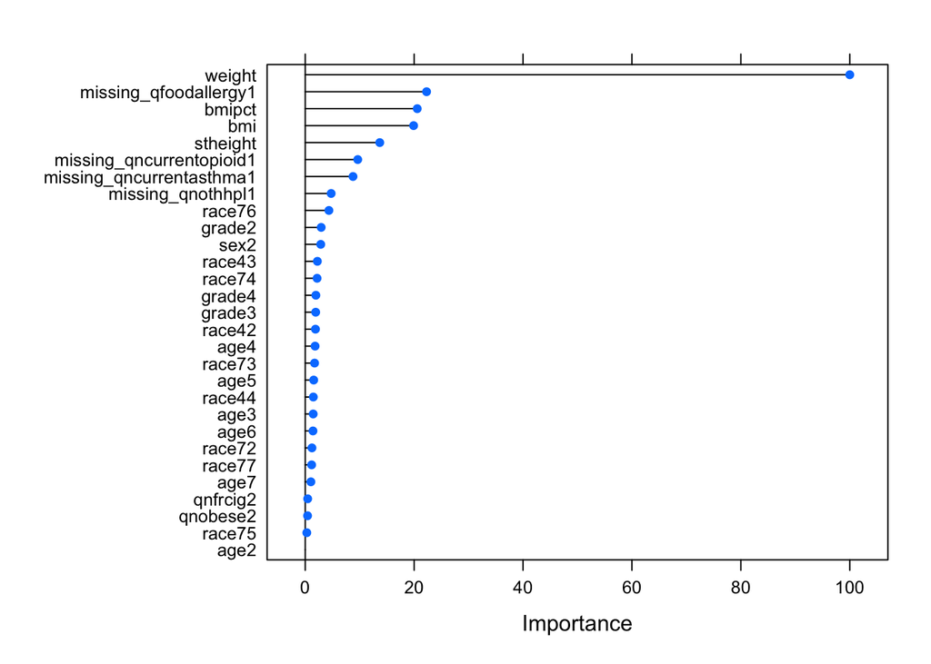

```r
plot(varImp(model_fit_1))
```

```r
confusionMatrix(model_fit_1)
```

```
## Cross-Validated (10 fold) Confusion Matrix
##
## (entries are percentual average cell counts across resamples)
##
##           Reference
## Prediction    0    1
##          0 86.6  4.1
##          1  2.3  7.0
##
##  Accuracy (average) : 0.9358
```

# model 2, Elastic Net method

```r
# model 2, chooses alpha and lambda via cross-validation using all of the features - Elastic Net method
set.seed(123)

# Construct k-folds in your data
trcontrol = trainControl(method = "cv", number = 10, sampling = "up")

# model 2 fit
model_fit_2 <- train(
  missing_sexid ~., data = train_data, method = "glmnet",
  trControl = trcontrol, preProc=c("center", "scale"), tuneLength = 10, metric = "Accuracy"
  )

# Print the values of alpha and lambda that gave best prediction
model_fit_2$bestTune
```

```
##    alpha    lambda
## 60   0.6 0.1174027
```

```r
# Print all of the options examined
model_fit_2$results
```

```
##     alpha       lambda  Accuracy     Kappa  AccuracySD     KappaSD
## 1     0.1 0.0000626543 0.7446936 0.2100826 0.003865600 0.007986788
## 2     0.1 0.0001447396 0.7446936 0.2100826 0.003865600 0.007986788
## 3     0.1 0.0003343671 0.7453598 0.2104292 0.003912210 0.008021506
## 4     0.1 0.0007724315 0.7475407 0.2120375 0.003836462 0.008192339
## 5     0.1 0.0017844168 0.7520942 0.2149921 0.003789189 0.008129367
## 6     0.1 0.0041222343 0.7600241 0.2191045 0.004363771 0.009531565
## 7     0.1 0.0095228960 0.7732100 0.2256738 0.004073665 0.009273034
## 8     0.1 0.0219991248 0.7826547 0.2229275 0.003291734 0.006304843
## 9     0.1 0.0508208316 0.7879656 0.2185010 0.002995837 0.008944029
## 10    0.1 0.1174027126 0.8060701 0.2337592 0.002489154 0.008601982
## 11    0.2 0.0000626543 0.7435986 0.2096687 0.004950108 0.008250534
## 12    0.2 0.0001447396 0.7437355 0.2096925 0.004927530 0.008225008
## 13    0.2 0.0003343671 0.7446754 0.2102515 0.004801841 0.008074443
## 14    0.2 0.0007724315 0.7474586 0.2125113 0.004613847 0.007918520
```

[output cut: 86 more lines]

```r
# Model coefficients
coef(model_fit_2$finalModel, model_fit_2$bestTune$lambda)
```

```
## 30 x 1 sparse Matrix of class "dgCMatrix"
##                                     s1
## (Intercept)               0.0090277636
## weight                    .
## age2                      .
## age3                      .
## age4                      .
## age5                      .
## age6                      .
## age7                      .
## sex2                      .
## grade2                    .
## grade3                    .
## grade4                    .
## race42                    .
## race43                    .
## race44                    .
## race72                    .
## race73                    .
## race74                    .
## race75                    .
## race76                    .
## race77                    .
## stheight                  .
## bmi                       .
## bmipct                    .
## qnobese2                  .
## qnfrcig2                  .
## missing_qnothhpl1         0.0006040233
## missing_qfoodallergy1    -0.3513307599
## missing_qncurrentasthma1  .
## missing_qncurrentopioid1 -0.0162349587
```

```r
# visualization and accuracy
varImp(model_fit_2)
```

```
## glmnet variable importance
##
##   only 20 most important variables shown (out of 29)
##
##                           Overall
## missing_qfoodallergy1    100.0000
## missing_qncurrentopioid1   4.6210
## missing_qnothhpl1          0.1719
## age3                       0.0000
## race44                     0.0000
## grade2                     0.0000
## race43                     0.0000
## race77                     0.0000
## race73                     0.0000
## race75                     0.0000
## age5                       0.0000
## race72                     0.0000
## bmipct                     0.0000
## age7                       0.0000
## grade3                     0.0000
## qnfrcig2                   0.0000
## bmi                        0.0000
## age4                       0.0000
## weight                     0.0000
## age2                       0.0000
```

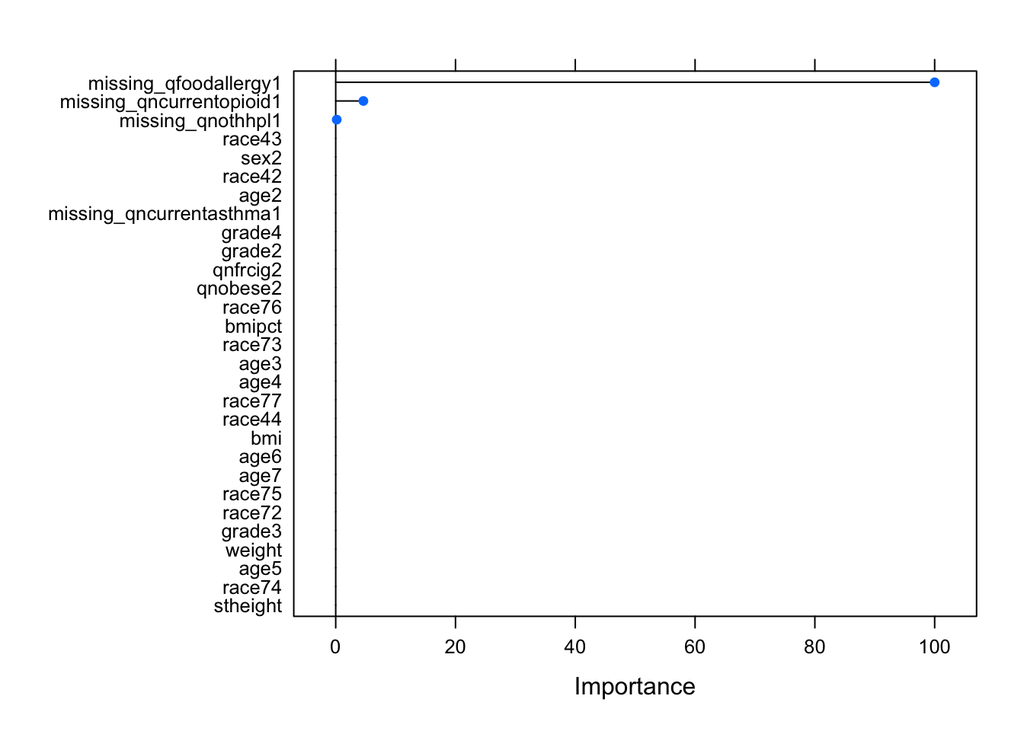

```r
plot(varImp(model_fit_2))
```

```r
confusionMatrix(model_fit_2)
```

```
## Cross-Validated (10 fold) Confusion Matrix
##
## (entries are percentual average cell counts across resamples)
##
##           Reference
## Prediction    0    1
##          0 88.9  8.8
##          1  0.0  2.3
##
##  Accuracy (average) : 0.9117
```

# model 3, random forest

```r
set.seed(123)
# Setting 5-fold cross-validation for fast demonstration.
control_settings<-trainControl(method = "cv", number = 10, sampling = "up")

# Trying three different values of mtry
mtry_vals_3 <- c(ncol(train_data)-1, sqrt(ncol(train_data)-1), 0.5*ncol(train_data)-1)
mtry_grid_3 <- expand.grid(.mtry = round(mtry_vals_3))

model_fit_3 <- train(
  missing_sexid ~., data = train_data, method = "rf", metric = "Accuracy",
  preProc=c("center", "scale"), tuneGrid = mtry_grid_3, trControl = control_settings,
  ntree=200
  )

confusionMatrix(model_fit_3)
```

```
## Cross-Validated (10 fold) Confusion Matrix
##
## (entries are percentual average cell counts across resamples)
##
##           Reference
## Prediction    0    1
##          0 86.7  4.1
##          1  2.2  7.0
##
##  Accuracy (average) : 0.9366
```

```r
model_fit_3$results
```

```
##   mtry  Accuracy     Kappa  AccuracySD     KappaSD
## 1    4 0.8134251 0.3978573 0.003898882 0.007203952
## 2    7 0.8877503 0.5292786 0.002476433 0.010283859
## 3   15 0.9366251 0.6535320 0.002261024 0.012450348
```

```r
model_fit_3$bestTune
```

```
##   mtry
## 3   15
```

```r
model_fit_3$finalModel
```

```
##
## Call:
##  randomForest(x = x, y = y, ntree = 200, mtry = param$mtry)
##                Type of random forest: classification
##                      Number of trees: 200
## No. of variables tried at each split: 15
##
##         OOB estimate of  error rate: 1.29%
## Confusion matrix:
##       0     1  class.error
## 0 94911  2509 0.0257544652
## 1    10 97410 0.0001026483
```

```r
varImp(model_fit_3)
```

```
## rf variable importance
##
##   only 20 most important variables shown (out of 29)
##
##                          Overall
## weight                   100.000
## missing_qfoodallergy1     22.129
## bmipct                    20.513
## bmi                       19.680
## stheight                  13.559
## missing_qncurrentopioid1   9.550
## missing_qncurrentasthma1   7.706
## missing_qnothhpl1          5.052
## race76                     4.495
## sex2                       2.852
## grade2                     2.814
## race74                     2.153
## race43                     2.142
## grade4                     2.038
## grade3                     1.886
## race73                     1.856
## age4                       1.820
## race42                     1.723
## age5                       1.603
## age6                       1.417
```

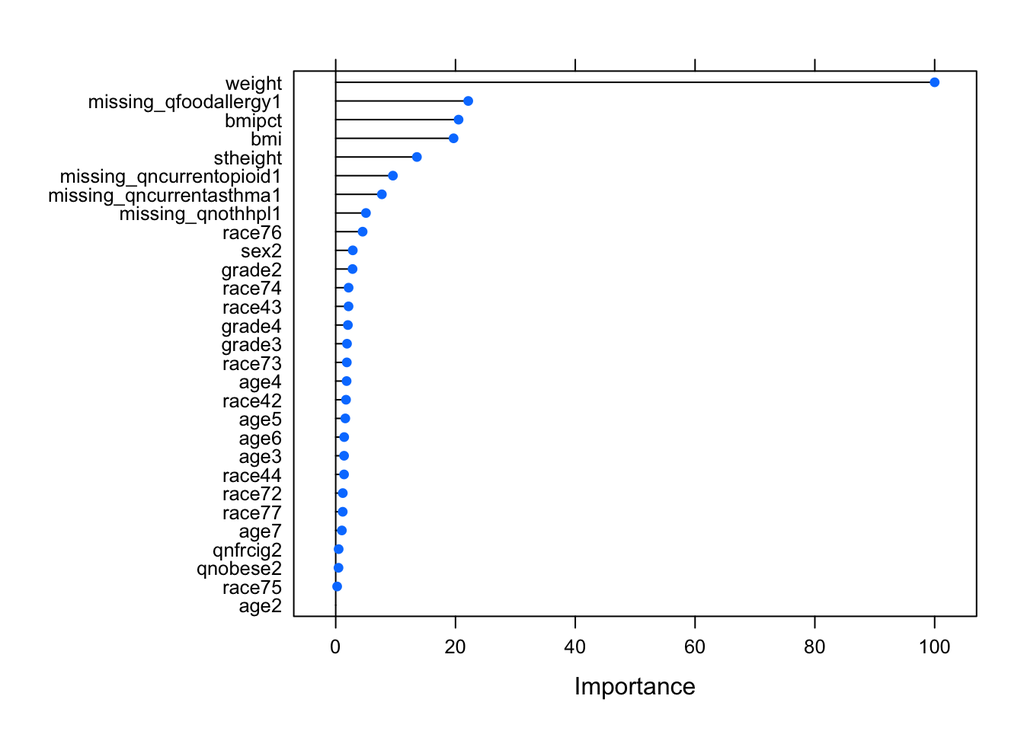

```r
plot(varImp(model_fit_3))
```

```r
# varImpPlot(model_fit_3$finalModel)
```

# model 4 boosting

```r
set.seed(123)

#First example where all hyperparameters are being held constant,  no cross-validation, using bootstrapping default

model_fit_boosting <- train(missing_sexid ~., data = train_data, method = "gbm", distribution = "bernoulli", verbose = F, tuneGrid = data.frame(.n.trees = 1000, .shrinkage = 0.001, .interaction.depth = 1, .n.minobsinnode = 10))

confusionMatrix(model_fit_boosting)
```

```
## Bootstrapped (25 reps) Confusion Matrix
##
## (entries are percentual average cell counts across resamples)
##
##           Reference
## Prediction    0    1
##          0 88.9  8.9
##          1  0.0  2.3
##
##  Accuracy (average) : 0.9115
```

```r
# varImp(model_fit_boosting)
#Second example where I tune hyperparameters
#set.seed(123)

#only running a few bootstrapped samples
#control.settings<-trainControl(number = 5)
#gbm.hyp <- expand.grid(n.trees = (0:10)*100, shrinkage = c(0.01, 0.001), interaction.depth = #c(1,3), n.minobsinnode = 10)

#model_fit_boosting_2 <- train(missing_sexid  ~., data = train_data, method = "gbm", #distribution = "bernoulli", verbose = F, tuneGrid = gbm.hyp, trControl = control.settings)

#confusionMatrix(model_fit_boosting_2)
# varImp(model_fit_boosting_2)
```